# **orchaRd 2.0: An R package for drawing ‘orchard’ plots (and ‘caterpillars’ plots) from meta-analyses and meta-regressions**

## 6.2 **Example 8: Leave-one-out in more complex models**

There are cases in which the meta-analytic model is more complicated. `leave_one_out()` can handle some common cases that try to account for non-independence including when the models have:

- A variance-covariance matrix for sampling variances, implemented with `metafor::vcalc()`
- Phylogenetic matrix, calculated with `ape::vcv()`
- Robust variance estimation, implemented with `metafor::robust()`

To demonstrate how this works, we will use a subset of the Pottier et al. (2021) data and fit a fictitious model.

```r
# Fictitious model just for the example
res <- rma.mv(yi = dARR,
              V = VCV,
              test = "t",
              random = list(~1 | study_ID,
                            ~1 | es_ID,
                            ~1 | species_ID,
                            ~1 | phylogeny),
              R = list(phylogeny = phylo_matrix),
              data = pottier_subset)

robust_res <- robust(res, cluster = study_ID)

mod_results(robust_res, group = "study_ID")
```

```
     name estimate lowerCL upperCL lowerPR upperPR
1 Intrcpt    0.084   -0.29    0.46   -0.86       1
```

To include those correlations in the leave-one-out analysis, we need to pass some extra arguments to the `leave_one_out()` function, so they can be re-calculated in each iteration. To see the details of the arguments, run `?leave_one_out()`.

```r
# vcalc_args must be a list with the arguments for vcalc. They must be
# passed as strings, except for rho, which is a number.
vcalc_args <- list(vi = "Var_dARR",
                   cluster = "study_ID",
                   obs = "es_ID",
                   rho = 0.5)

# phylo_args must be a list with the arguments for vcv. They must be
# the phylogenetic tree object, and a string with the name of the
# species names column that is used as random effect.
phylo_args <- list(tree = tree,
                   species_colname = "phylogeny")

# robust_args must be a list with the arguments for robust. For the moment,
# it only accepts cluster as a string, and clubSandwich as TRUE or FALSE.
robust_args <- list(cluster = "study_ID")

loo_test_phylo <- leave_one_out(res,
                                group = "phylogeny",
                                vcalc_args = vcalc_args,
                                phylo_args = phylo_args,
                                robust_args = robust_args)

loo_test_phylo
```

```
                name estimate lowerCL upperCL lowerPR upperPR
1 Amalosia_lesueurii    0.095   -0.46    0.65   -1.18    1.37
2       Tor_putitora   -0.013   -0.39    0.36   -0.88    0.85
3       Labeo_rohita    0.135   -0.20    0.47   -0.77    1.04
4        Danio_rerio    0.042   -0.49    0.57   -1.17    1.26
5  Propylea_japonica    0.110   -0.43    0.65   -1.13    1.35
```

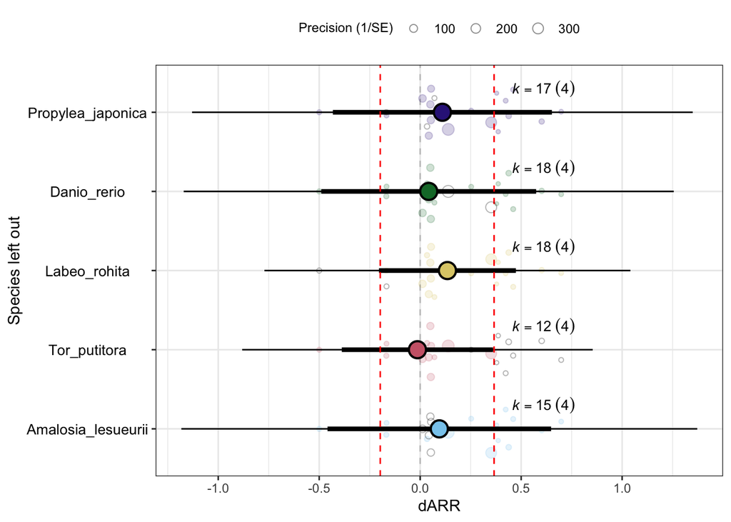

Figure 31— Leave-one-out analysis of the meta-analysis of Pottier et al. (2021). The y-axis shows which species was left out, and the x-axis shows the effect size (dARR) for each model.

```r
orchard_leave1out(leave1out = loo_test_phylo,
                  xlab = "dARR",
                  ylab = "Species left out",
                  trunk.size = 1.2,
                  branch.size = 1.5,
                  alpha = 0.2,
                  legend.pos = "top.out")
```

Note that this time the leave-one-out was done by species, not by study. You can leave out one study at a time and still use phylogeny:

```r
loo_test_stdy <- leave_one_out(res,
                          group = "study_ID",
                          vcalc_args = vcalc_args,
                          phylo_args = phylo_args,
                          robust_args = robust_args)
loo_test_stdy
```

```
  name estimate lowerCL upperCL lowerPR upperPR
1    1    0.095   -0.46    0.65   -1.18    1.37
2    2   -0.013   -0.39    0.36   -0.88    0.85
3    4    0.135   -0.20    0.47   -0.77    1.04
4    5    0.042   -0.49    0.57   -1.17    1.26
5    6    0.110   -0.43    0.65   -1.13    1.35
```

Finally, you can use the output from `leave_one_out()` to plot the results using `ggplot2` if you like:

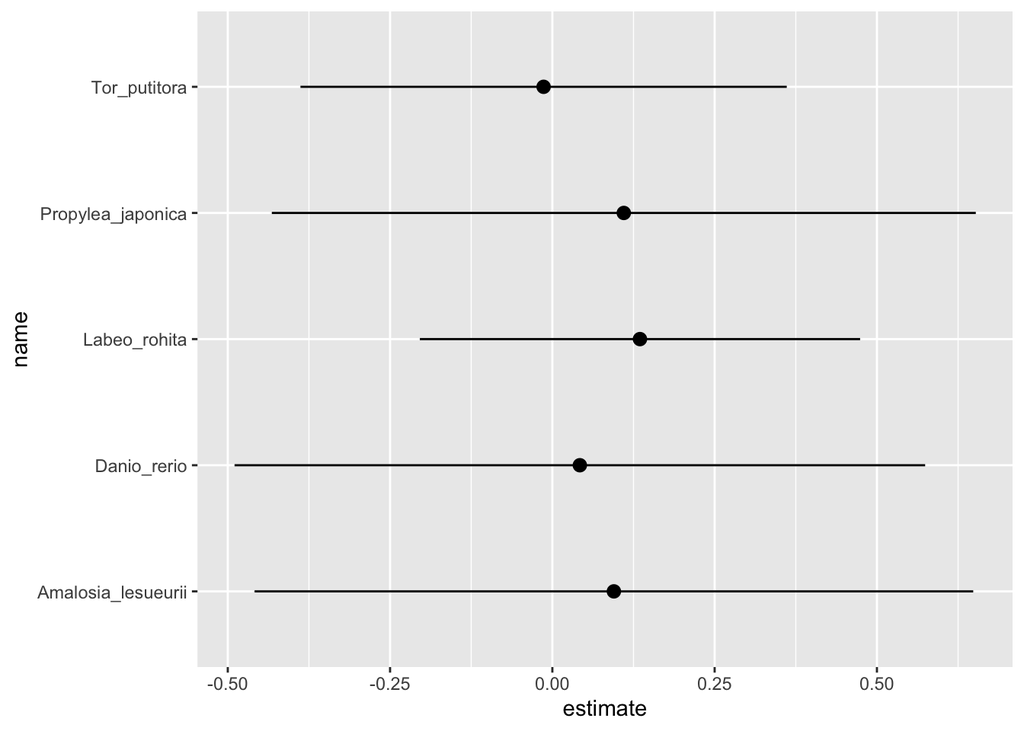

Figure 32— Leave-one-out analysis of the meta-analysis of Pottier et al. (2021). The y-axis shows which species was left out, and the x-axis shows the effect size (dARR) for each model.

```r
library(ggplot2)

loo_test_phylo$mod_table |>
  ggplot(aes(x = name, y = estimate, ymin = lowerCL, ymax = upperCL)) +
  geom_pointrange() +
  coord_flip()
```

# 7 *New* Converting `glmmTMB` Models for use with `orchaRd`

Recent developments in `glmmTMB` mean that users can fit multilevel meta-analytic models outside of `metafor`, while retaining a highly flexible mixed-model framework. To make these models work with `orchaRd`, we have added the function `glmmTMB_to_rma()`. This function takes a fitted `glmmTMB` model and wraps it in an object that behaves like an `rma.mv` model for the purposes of `orchaRd` plotting and summary functions.

In practice, this means users can fit a model with `glmmTMB`, convert it, and then pass it directly to `mod_results()`, `orchard_plot()`, `bubble_plot()`, `caterpillars()`, `i2_ml()`, and related summaries.

## 7.1 **Example 9: Converting a `glmmTMB` model and using it with `orchaRd`**

It is now possible to fit mixed models in `glmmTMB` (Williams et al. 2026) and convert them for use with `orchaRd`. To demonstrate how this works with a real example from this vignette, we return to the fish dataset from Example 6 and fit a model with both a categorical moderator (`trait.type`) and a continuous moderator (`deg_dif`). We then convert the fitted `glmmTMB` object with `glmmTMB_to_rma()` and use it directly in `orchaRd`.

```r
library(glmmTMB)

data(fish)

fish_tmb <- fish
fish_tmb$obs <- factor(1:nrow(fish_tmb))
fish_tmb$g  <- 1L #constant grouping variable for the residual variance structure
```

We now fit the corresponding `metafor` and `glmmTMB` models:

```r
fish_meta <- metafor::rma.mv(
  yi = lnrr,
  V = lnrr_vi,
  mods = ~ trait.type + deg_dif,
  random = list(~1 | group_ID, ~1 | obs),
  data = fish_tmb
)

V <- diag(fish_tmb$lnrr_vi)

fish_glmmTMB <- glmmTMB(
  lnrr ~ trait.type + deg_dif + (1 | group_ID) + equalto(0 + obs | g, V),
  data = fish_tmb,
  REML = TRUE
)

summary(fish_meta)
```

```
Multivariate Meta-Analysis Model (k = 410; method: REML)

  logLik  Deviance       AIC       BIC      AICc
 43.0118  -86.0235  -72.0235  -43.9963  -71.7414

Variance Components:

            estim    sqrt  nlvls  fixed    factor
sigma^2.1  0.0151  0.1229     84     no  group_ID
sigma^2.2  0.0259  0.1610    410     no       obs

Test for Residual Heterogeneity:
QE(df = 405) = 39046.8523, p-val < .0001

Test of Moderators (coefficients 2:5):
QM(df = 4) = 35.5829, p-val < .0001

Model Results:

                        estimate      se     zval    pval    ci.lb   ci.ub
intrcpt                   0.1625  0.1439   1.1289  0.2590  -0.1196  0.4446
trait.typelife-history    0.4990  0.1805   2.7647  0.0057   0.1452  0.8527  **
trait.typemorphology     -0.1271  0.1436  -0.8851  0.3761  -0.4087  0.1544
trait.typephysiology     -0.1165  0.1464  -0.7957  0.4262  -0.4034  0.1704
deg_dif                  -0.0078  0.0053  -1.4675  0.1422  -0.0182  0.0026

---
Signif. codes:  0 '***' 0.001 '**' 0.01 '*' 0.05 '.' 0.1 ' ' 1
```

```r
summary(fish_glmmTMB)
```

```
 Family: gaussian  ( identity )
Formula:
lnrr ~ trait.type + deg_dif + (1 | group_ID) + equalto(0 + obs |      g, V)
Data: fish_tmb

      AIC       BIC    logLik -2*log(L)  df.resid
      -52       -23        33       -66       403

Random effects:

Conditional model:
 Groups   Name        Variance Std.Dev. Corr
 group_ID (Intercept) 1.51e-02 0.122876
 g        obs1        2.76e-05 0.005249
          obs2        1.11e-03 0.033357 0.00
          obs3        5.07e-04 0.022525 0.00 0.00
          obs4        5.43e-02 0.233112 0.00 0.00 0.00
          obs5        1.95e-01 0.442069 0.00 0.00 0.00 0.00
          obs6        5.22e-05 0.007224 0.00 0.00 0.00 0.00 0.00
          obs7        1.75e-04 0.013232 0.00 0.00 0.00 0.00 0.00 0.00
          obs8        3.91e-04 0.019764 0.00 0.00 0.00 0.00 0.00 0.00 0.00
          obs9        1.09e-02 0.104494 0.00 0.00 0.00 0.00 0.00 0.00 0.00 0.00
          obs10       4.25e-04 0.020606 0.00 0.00 0.00 0.00 0.00 0.00 0.00 0.00
          ...         ...      ...      ...  ...  ...  ...  ...  ...  ...  ...
 Residual             2.59e-02 0.160997











 0.00
 ...  ...

Number of obs: 410, groups:  group_ID, 84; g, 1

Dispersion estimate for gaussian family (sigma^2): 0.0259

Conditional model:
                       Estimate Std. Error z value Pr(>|z|)
(Intercept)             0.16248    0.14400    1.13   0.2592
trait.typelife-history  0.49896    0.18052    2.76   0.0057 **
trait.typemorphology   -0.12714    0.14370   -0.88   0.3763
trait.typephysiology   -0.11648    0.14645   -0.80   0.4264
deg_dif                -0.00780    0.00531   -1.47   0.1423
---
Signif. codes:  0 '***' 0.001 '**' 0.01 '*' 0.05 '.' 0.1 ' ' 1
```

To interface this model with `orchaRd`, we convert it using `glmmTMB_to_rma()`:

```r
fish_tmb_rma <- glmmTMB_to_rma(
  fish_glmmTMB,
  yi = "lnrr",
  vi = "lnrr_vi",
  data = fish_tmb,
  measure = "GEN"
)

class(fish_tmb_rma)
```

```
[1] "rma.mv" "rma"
```

Before plotting the results, we can check that the `metafor` and `glmmTMB` fits agree closely in their fixed effects:

```r
fe_compare <- data.frame(
  Term = rownames(fish_meta$b),
  metafor = round(as.numeric(fish_meta$b), 4),
  glmmTMB_conv = round(as.numeric(fish_tmb_rma$b), 4)
)

knitr::kable(fe_compare, caption = "Fixed effects comparison between metafor and glmmTMB")
```

Fixed effects comparison between metafor and glmmTMB

| Term | metafor | glmmTMB_conv |
| --- | --- | --- |
| intrcpt | 0.16 | 0.16 |
| trait.typelife-history | 0.50 | 0.50 |
| trait.typemorphology | -0.13 | -0.13 |
| trait.typephysiology | -0.12 | -0.12 |
| deg_dif | -0.01 | -0.01 |

Once converted, we can use the `glmmTMB` model exactly as we would a fitted `metafor` model. First, we can recreate an orchard plot for the categorical moderator:

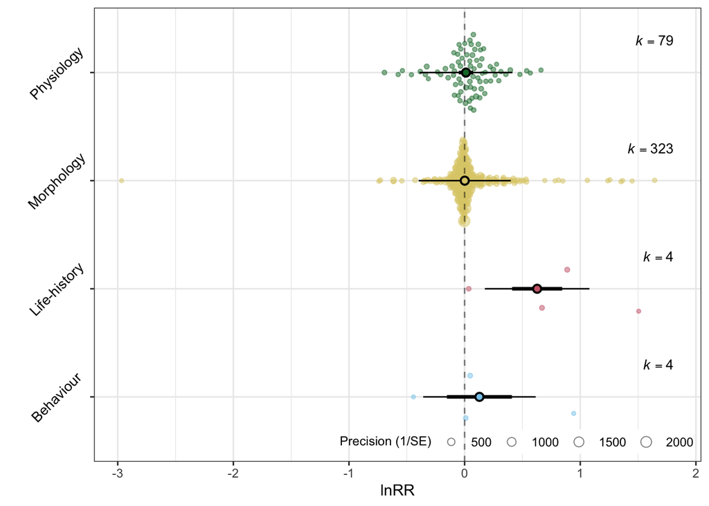

Figure 33— Orchard plot from a `glmmTMB` model fit to the fish dataset and converted for use with `orchaRd`.

```r
fish_trait_tmb <- orchaRd::mod_results(
  fish_tmb_rma,
  mod = "trait.type",
  group = "group_ID"
)

orchaRd::orchard_plot(
  fish_trait_tmb,
  xlab = "lnRR",
  angle = 45,
  g = FALSE
)
```

And because the same converted object retains the sampling variances and model matrix needed by `orchaRd`, we can also create a bubble plot for the continuous moderator:

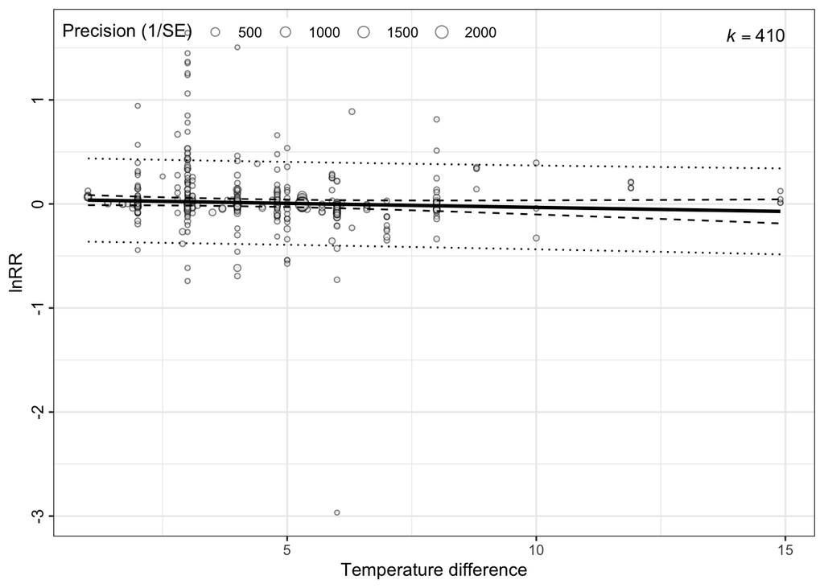

Figure 34— Bubble plot from a `glmmTMB` model fit to the fish dataset and converted for use with `orchaRd`.

```r
orchaRd::bubble_plot(
  fish_tmb_rma,
  mod = "deg_dif",
  group = "group_ID",
  xlab = "Temperature difference",
  ylab = "lnRR",
  legend.pos = "top.left"
)
```

We can also calculate common heterogeneity summaries directly from the converted object:

```r
i2_ml(fish_tmb_rma, method = "ratio")
```

```
   I2_Total I2_group_ID I2_Residual
        100          37          63
```

At present, the conversion pathway is intended for downstream plotting and summary of a fitted `glmmTMB` model. Procedures that require repeated refitting of a `metafor` model, such as bootstrap refits in some helper functions or the current `leave_one_out()` workflow, are not yet implemented for converted objects.

# 8 *New* Bias-Corrected Meta-analytic Mean Plots

Publication bias is a common issue in meta-analysis but can be challenging to deal with the multi-level meta-analyses (S. Nakagawa et al. 2022). Yang et al. (2024) proposed a new method to correct for publication bias in multi-level meta-analyses. We have implemented a new plot which can visualise how overall meta-analytic means change when correcting for publication bias. This is done using the `pub_bias_plot()` function.

```r
# Data
data(english)

# We need to calculate the effect sizes, in this case d
english <- metafor::escalc(measure = "SMD", n1i = NStartControl, sd1i = SD_C, m1i = MeanC, n2i = NStartExpt, sd2i = SD_E, m2i = MeanE,
                var.names=c("SMD","vSMD"),
                data = english)

# Our MLMA model
english_MA1 <- metafor::rma.mv(yi = SMD, V = vSMD, random = list( ~ 1 | StudyNo, ~ 1 | EffectID),test = "t", data = english)

 # Now apply the approach of Yang et al. 2024
# Step 1: Fit the fixed effect model
english_MA2 <- metafor::rma(yi = SMD, vi = vSMD, data = english, test = "t", method = "FE")

# Step 2: Correct for dependency
english_MA2_1 <- metafor::robust(english_MA2, cluster = english$StudyNo, clubSandwich=TRUE)

# Step 3: Testing modified eggers. Need intercept following Nakagawa et al. 2022
english_MA4 <- metafor::rma.mv(yi = SMD, V = vSMD, mod = ~vSMD, random = list( ~ 1 | StudyNo, ~ 1 | EffectID),test = "t", data = english)
```

We can then plot the results using the `pub_bias_plot()` function. This function takes the output of `orchard_plot()` and adds the bias-corrected mean estimates (Fig. 35).

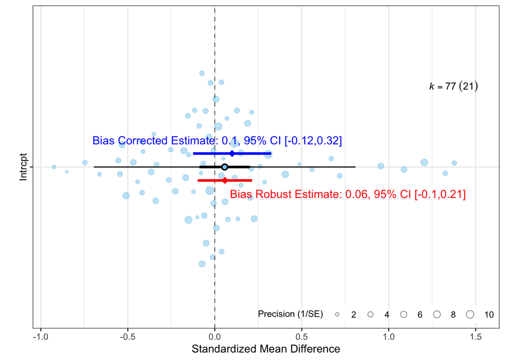

```r
 plot <- orchard_plot(english_MA1, group = "StudyNo",  xlab = "Standardized Mean Difference")
plot2 <- pub_bias_plot(plot, english_MA2_1, english_MA4)
plot2
```

# 9 **Combining orchard plots with summary tables**

A common request (see [#93](https://github.com/daniel1noble/orchaRd/issues/93), contributed by `@EIvimeyCook`) is to display an orchard plot together with a formatted summary table of model coefficients and heterogeneity statistics in a single figure. This can be done by pairing `orchard_plot()` with `broom::tidy()`, `gt`, and `patchwork`. The example below refits the `lim` meta-regression from *Example 3* and stacks a styled `gt` table above the orchard plot.

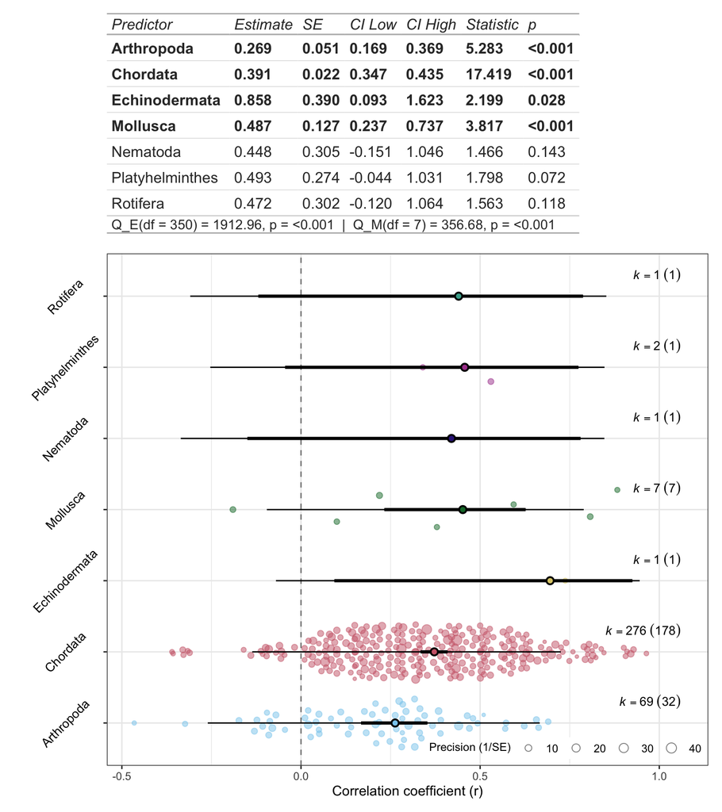

Figure 36— Orchard plot of the lim meta-regression combined with a styled `gt` summary table via `patchwork`. The table reports coefficient-level estimates, confidence intervals, and test statistics; the source note reports heterogeneity (Q_E) and omnibus moderator (Q_M) tests extracted from the `rma.mv` object.

```r
library(broom)
library(gt)
library(patchwork)
library(dplyr)

# Refit the lim meta-regression (same specification as Example 3)
data(lim)
lim$vi <- (1/sqrt(lim$N - 3))^2
lim_MR <- metafor::rma.mv(yi = yi, V = vi, mods = ~ Phylum - 1,
                          random = list(~1 | Article, ~1 | Datapoint),
                          data = lim)

# Orchard plot of the lim meta-regression
gg_orchard <- orchaRd::orchard_plot(lim_MR, mod = "Phylum", group = "Article",
                                    xlab = "Correlation coefficient (r)",
                                    transfm = "tanh", angle = 45, cb = TRUE)

# Tidy the model coefficients and format for display.
# Keep the raw numeric p in `p_num` so we can drive conditional styling from it.
tidy_raw <- broom::tidy(lim_MR, conf.int = TRUE)
coef_tab <- tidy_raw |>
  dplyr::mutate(
    Predictor = sub("^Phylum", "", term),
    Estimate  = sprintf("%.3f", estimate),
    SE        = sprintf("%.3f", std.error),
    `CI Low`  = sprintf("%.3f", conf.low),
    `CI High` = sprintf("%.3f", conf.high),
    Statistic = sprintf("%.3f", statistic),
    p         = ifelse(p.value < 0.001, "<0.001", sprintf("%.3f", p.value)),
    p_num     = p.value
  ) |>
  dplyr::select(Predictor, Estimate, SE, `CI Low`, `CI High`, Statistic, p, p_num)

# Heterogeneity and omnibus moderator stats pulled from the rma.mv object
src_note <- paste0(
  "Q_E(df = ", lim_MR$k - lim_MR$p, ") = ", round(lim_MR$QE, 2),
  ", p = ", ifelse(lim_MR$QEp < 0.001, "<0.001", round(lim_MR$QEp, 3)),
  "  |  Q_M(df = ", lim_MR$QMdf[1], ") = ", round(lim_MR$QM, 2),
  ", p = ", ifelse(lim_MR$QMp < 0.001, "<0.001", round(lim_MR$QMp, 3))
)

gt_tab <- gt::gt(coef_tab) |>
  gt::tab_style(style = gt::cell_text(weight = "bold"),
                locations = gt::cells_body(rows = p_num < 0.05)) |>
  gt::cols_hide(columns = "p_num") |>
  gt::tab_style(style = gt::cell_text(style = "italic"),
                locations = gt::cells_column_labels()) |>
  gt::tab_style(style = gt::cell_borders(sides = "bottom", color = "black",
                                         weight = gt::px(3)),
                locations = gt::cells_column_labels()) |>
  gt::cols_align("left") |>
  gt::tab_source_note(source_note = src_note)

# Stack the table above the orchard plot; give the plot more vertical space
patchwork::wrap_table(gt_tab) / gg_orchard +
  patchwork::plot_layout(heights = c(2, 5))
```

The same pattern works for any `rma`/`rma.mv` model: `broom::tidy(..., conf.int = TRUE)` yields one row per coefficient, `gt` handles formatting/styling, and `patchwork::wrap_table()` lets the table participate in a `patchwork` layout alongside the orchard plot. To display a publication-bias-corrected orchard plot alongside the raw coefficient table, pass a bias-correction moderator to `mod_results()` via the `at` argument (e.g. `at = list(vi = 0)`) and plot that result in place of `lim_MR`.

## 10 References

Clarke, E., and S. Sherrill-Mix. 2017. “Ggbeeswarm: Categorical Scatter (Violin Point) Plots.” *R Package Version 0.6.0*.

Eklof, J. S., C. Alsterberg, J. N. Havenhand, K. Sundback, H. L. Wood, and L. Gamfeldt. 2012. “Experimental Climate Change Weakens the Insurance Effect of Biodiversity.” *Ecology Letters* 15: 864–72.

Eklund, A. 2012. “Beeswarm: The Bee Swarm Plot, an Alternative to Stripchart.” *R Package Version 0.1.*

English, Sinead, and Tobias Uller. 2016. “Does Early-Life Diet Affect Longevity? A Meta-Analysis Across Experimental Studies.” *Biology Letters* 12: 20160291.

Lim, J. N., A. M. Senior, and S. Nakagawa. 2014. “Heterogeneity in Individual Quality and Reproductive Trade-Offs Within Species.” *Evolution* 68 (8): 2306–18. doi: 10.1111/evo.12446.

Nakagawa, Shinichi, Yefeng Yang, Erin L Macartney, Rebecca Spake, and Malgorzata Lagisz. 2023. “Quantitative Evidence Synthesis: A Practical Guide on Meta-Analysis, Meta-Regression, and Publication Bias Tests for Environmental Sciences.” *Environmental Evidence* 12 (1): 8.

Nakagawa, S., Malgorzata Lagisz, Michael D. Jennions, Julia Koricheva, Daniel W. A. Noble, Timothy H. Parker, Alfredo Sánchez-Tójar, Yefeng Yang, and Rose E. O’Dea. 2022. “Methods for Testing Publication Bias in Ecological and Evolutionary Meta-Analyses.” *Methods in Ecology and Evolution* 13 (1): 4–21.

Nakagawa, S, and E. S. A. Santos. 2012. “Methodological Issues and Advances in Biological Meta-Analysis.” *Evolutionary Ecology* 26 (5): 1253–1274.

Nakagawa, S., and H. Schielzeth. 2013. “A General and Simple Method for Obtaining R2 from Generalized Linear Mixed‐effects Models.” *Methods in Ecology and Evolution* 4 (2): 133–42.

O’Dea, Rose E., Malgorzata Lagisz, Andrew P. Hendry, and Shinichi Nakagawa. 2019. “Developmental Temperature Affects Phenotypic Means and Variability: A Meta-Analysis of Fish Data.” *Fish and Fisheries* 20: 1005–22.

Pottier, Patrice, Samantha Burke, Szymon M Drobniak, Malgorzata Lagisz, and Shinichi Nakagawa. 2021. “Sexual (in) Equality? A Meta‐analysis of Sex Differences in Thermal Acclimation Capacity Across Ectotherms.” *Functional Ecology* in press: https://doi.org/10.1111/1365–2435.13899.

Senior, A. M., C. E. Grueber, T. Kamiya, M. Lagisz, K. O’Dwyer, E. S. A. Santos, and Nakagawa S. 2016. “Heterogeneity in Ecological and Evolutionary Meta-Analyses: Its Magnitudes and Implications.” *Ecology* 97 (12): 3293–99.

Senior, Alistair M., Shinichi Nakagawa, David Raubenheimer, Steven J Simpson, and Daniel W. A. Noble. 2017. “Dietary Restriction Increases Variability in Longevity.” *Biology Letters* 13 (3): 20170057.

Sherrill-Mix, S., and E. Clarke. 2017. “Plot Categorical Data Using Quasirandom Noise and Density Estimates.” *R Package Version 0.4.5.*

Viechtbauer, Wolfgang. 2010. “Conducting Meta-Analyses in r with the Metafor Package.” *Journal of Statistical Software* 363: 1–48.

Wickham, H. 2009. “Ggplot2: Elegant Graphics for Data Analysis.” *New York ; London: Springer*.

Williams, Coralie, Maeve McGillycuddy, Mollie Brooks, Benjamin M. Bolker, Ayumi Mizuno, Yefeng Yang, Wolfgang Viechtbauer, David I. Warton, and Shinichi Nakagawa. 2026. “Meta-Analysis with the glmmTMB r Package.” *arXiv*. https://doi.org/10.48550/arXiv.2604.04084.

Yang, Yefeng, Malgorzata Lagisz, Coralie Williams, Daniel W. A. Noble, Jinming Pan, and Shinichi Nakagawa. 2024. “Robust Point and Variance Estimation for Meta-Analyses with Selective Reporting and Dependent Effect Sizes.” *Methods in Ecology and Evolution* 15 (9): 1593–1610.